# G1401231088_Alden Nabil Wibowo Effedy_Tugas 4

### Identifikasi Stasioneritas

```r
theta <- c(0.4, 0.6)
# Cek akar MA (invertibel jika semua modulus > 1)
Mod(polyroot(c(1,  theta))) # akar polinom MA: 1 + 0.4 z + 0.6 z^2 = 0
```

```
## [1] 1.290994 1.290994
```

### Plot ACF, PACF, EACF

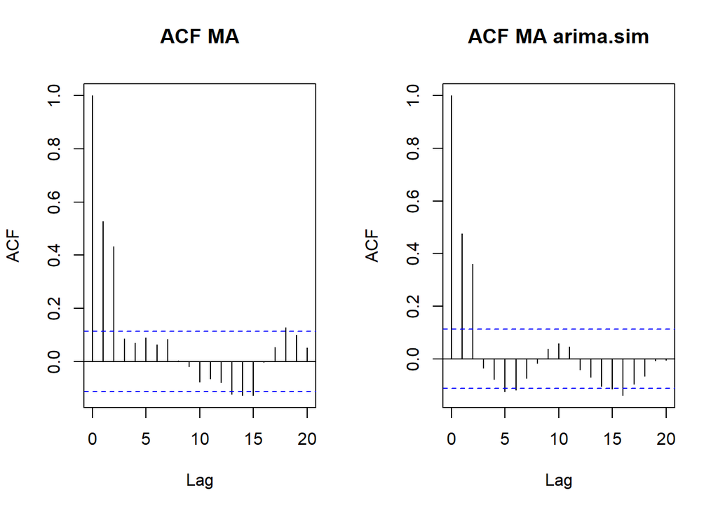

```r
par(mfrow = c(1, 2))
acf(ma, lag.max = 20, main = "ACF MA")
acf(ma2, lag.max = 20, main = "ACF MA arima.sim")
```

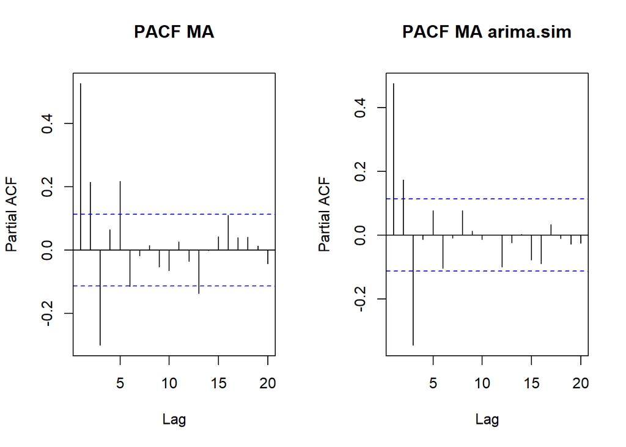

```r
par(mfrow = c(1, 2))
pacf(ma, lag.max = 20, main = "PACF MA")
pacf(ma2, lag.max = 20, main = "PACF MA arima.sim")
```

```r
TSA::eacf(ma)
```

```
## AR/MA
##   0 1 2 3 4 5 6 7 8 9 10 11 12 13
## 0 x x o o o o o o o o o  o  x  x
## 1 x x x o o o o o o o o  o  o  o
## 2 x x x x o o o o o o o  o  o  o
## 3 x x x x x o o o o o o  o  o  o
## 4 x x x x x o o o o o o  o  o  o
## 5 x x x x x o x o o o o  o  o  o
## 6 x x x o x o o x o o o  o  o  o
## 7 x o x o x o o x o o o  o  o  o
```

```r
TSA::eacf(ma2)
```

```
## AR/MA
##   0 1 2 3 4 5 6 7 8 9 10 11 12 13
## 0 x x o o x x o o o o o  o  o  o
## 1 x x x o o o o o o o o  o  o  o
## 2 x x x o o o o o o o o  o  o  o
## 3 o x x x o o o o o o o  o  o  o
## 4 x o x x x o o o o o o  o  o  o
## 5 x x x x x x o o o o o  o  o  o
## 6 o x x x o o o o o o o  o  o  o
## 7 x x x x o o o o o o o  o  o  o
```

  Kesimpulan: Model susah sesuai dengan karakteristik $MA(2)$

## Scatterplot AntarLag

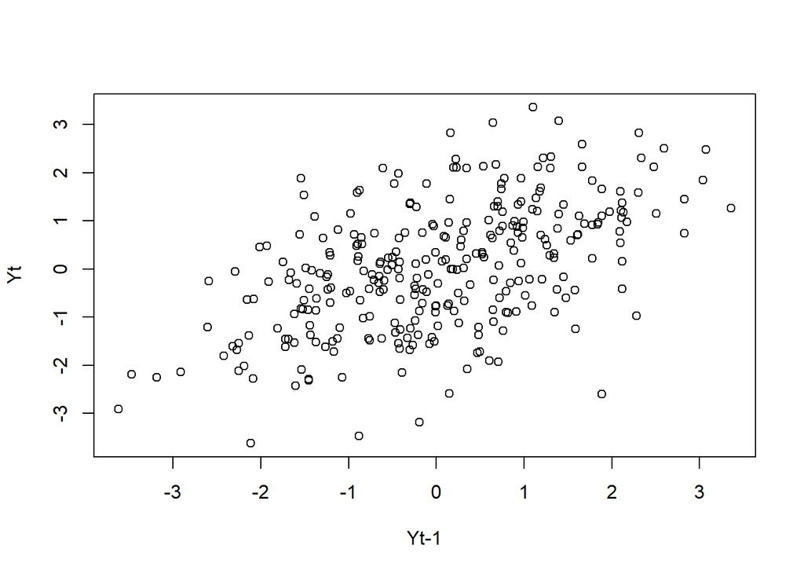

```r
#Yt
yt_ma <- ma[-1]
#Yt-1
yt_1_ma <- ma[-300]
plot(y=yt_ma,x=yt_1_ma, xlab = "Yt-1", ylab = "Yt")
```

```r
cor(yt_ma,yt_1_ma)
```

```
## [1] 0.5274606
```

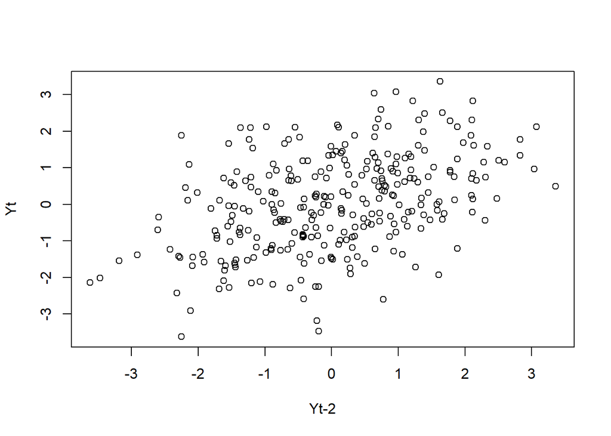

```r
#Yt
yt_ma2 <- ma[-c(1,2)]
#Yt-2
yt_2_ma <- ma[-c(299,300)]
plot(y=yt_ma2,x=yt_2_ma, xlab = "Yt-2", ylab = "Yt")
```

```r
cor(yt_ma2,yt_2_ma)
```

```
## [1] 0.4339293
```

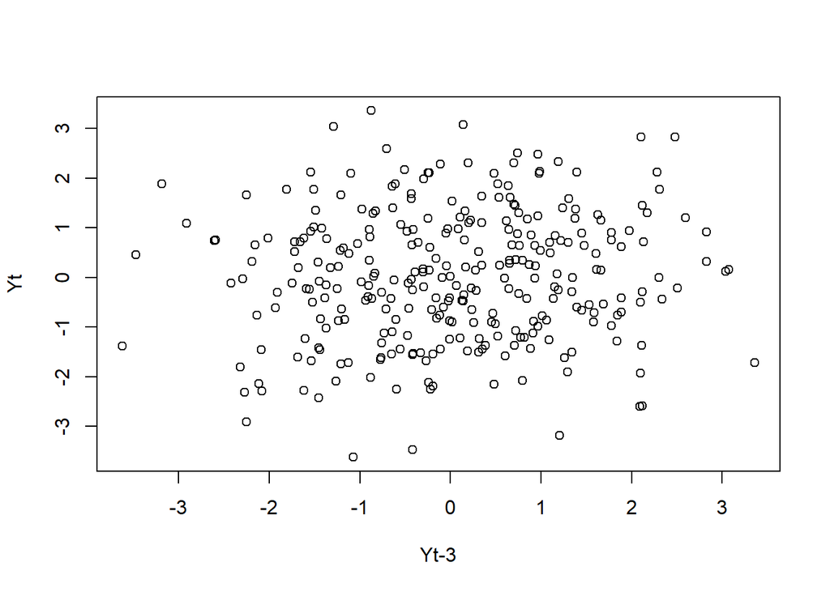

```r
#Yt
yt_ma3 <- ma[-c(1,2,3)]
#Yt-3
yt_3_ma <- ma[-c(298,299,300)]
plot(y=yt_ma3,x=yt_3_ma, xlab = "Yt-3", ylab = "Yt")
```

```r
cor(yt_ma3,yt_3_ma)
```

```
## [1] 0.08555282
```

## Autokorelasi

• Hitung autokorelasi masing masing baik dari data bangkitan maupun secara teoriti

### ACF Bangkitan

```r
## ACF empiris pakai acf() (langsung dapat semua lag sekaligus)
L <- 3  # banyak lag yang ingin dilihat
acf_ma  <- drop(acf(ma,  lag.max = L, plot = FALSE)$acf)   # untuk 'ma' (manual)
acf_ma2 <- drop(acf(ma2, lag.max = L, plot = FALSE)$acf)   # untuk 'ma2' (arima.sim)

acf_ma
```

```
## [1] 1.00000000 0.52664378 0.43311753 0.08537203
```

```r
acf_ma2
```

```
## [1]  1.00000000  0.47473144  0.35949296 -0.03608089
```

### ACF Teoritis

```r
theo_acf <- ARMAacf(ma = c(0.4, 0.6), lag.max = 5)  # termasuk lag 0
theo_acf[1:L+1]  # lihat beberapa lag awal: 0..5
```

```
##         1         2         3
## 0.4210526 0.3947368 0.0000000
```

### Perbandingan

```r
emp_ma  <- drop(acf(ma,  lag.max = L, plot = FALSE)$acf)
emp_ma2 <- drop(acf(ma2, lag.max = L, plot = FALSE)$acf)
theo    <- ARMAacf(ma = c(0.4, 0.6), lag.max = L)

compare_df <- data.frame(
  Lag              = 0:L,
  Empirical_manual = round(emp_ma,  6),
  Empirical_sim    = round(emp_ma2, 6),
  Theoretical      = round(theo,     6)
)
print(compare_df, row.names = FALSE)
```

```
##  Lag Empirical_manual Empirical_sim Theoretical
##    0         1.000000      1.000000    1.000000
##    1         0.526644      0.474731    0.421053
##    2         0.433118      0.359493    0.394737
##    3         0.085372     -0.036081    0.000000
```

Baik model $manual$ maupun $arima.sim$ mereplikasi ACF teoretis. $arima.sim$ lebih dekat kepada teori

# Model AR(2) $𝜙_1$=0.5, $𝜙_2$=0.2

## Pembangkitan Model

### Manual

```r
# Bangkitkan AR(2)
ar <- wn
for(i in 3:300){
   ar[i] <- wn[i] + 0.5 * ar[i - 1] + 0.2 * ar[i - 2]
}
summary(ar)
```

```
##     Min.  1st Qu.   Median     Mean  3rd Qu.     Max.
## -3.98255 -0.85115  0.08085  0.04610  1.08819  3.92790
```

### Arima.Sim

```r
ar2 <- arima.sim(list(order=c(2,0,0), ar=c(0.5, 0.2)), n=300)
summary(ar2)
```

```
##    Min. 1st Qu.  Median    Mean 3rd Qu.    Max.
## -3.1037 -0.9151 -0.2044 -0.1675  0.6787  3.5582
```

### Perbandingan

```r
compare_ar <- data.frame(
  Manual = ar,   Sim = ar2)
compare_ar
```

[output not shown]

[output cut: 286 more lines]

## Plot eksplorasi

### Plot Time Series

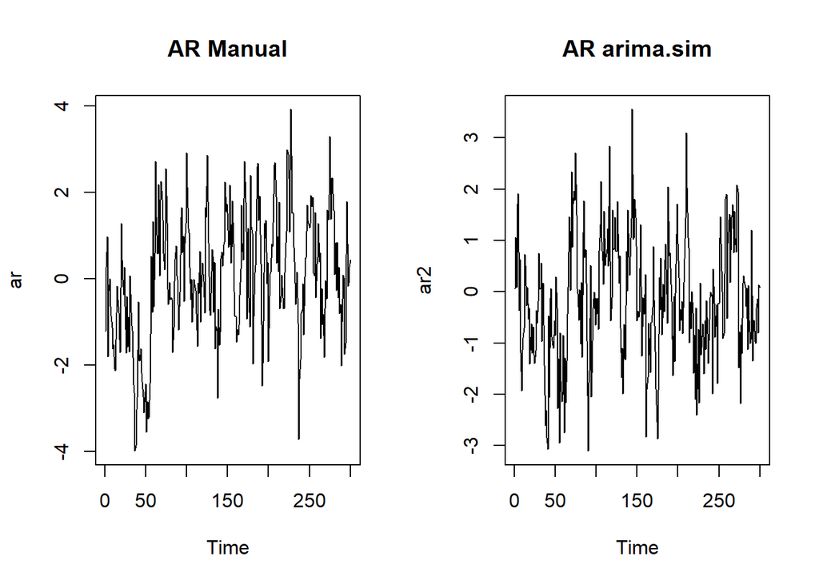

```r
par(mfrow = c(1, 2))
ts.plot(ar, main="AR Manual")
ts.plot(ar2, main="AR arima.sim")
```

### Identifikasi Stasioneritas

```r
phi   <- c(0.5, 0.2)
# Cek akar AR (stasioner jika semua modulus > 1)
Mod(polyroot(c(1, -phi)))   # akar polinom AR: 1 - 0.5 z - 0.2 z^2 = 0 # (b) Cek akar MA
```

```
## [1] 1.311738 3.811738
```

Berdasarkan plot time series dan identifikasi stasioneritas, terlihat bahwa data AR(2) yang dibangkitkan stasioner dalam rataan

### Plot ACF, PACF, EACF

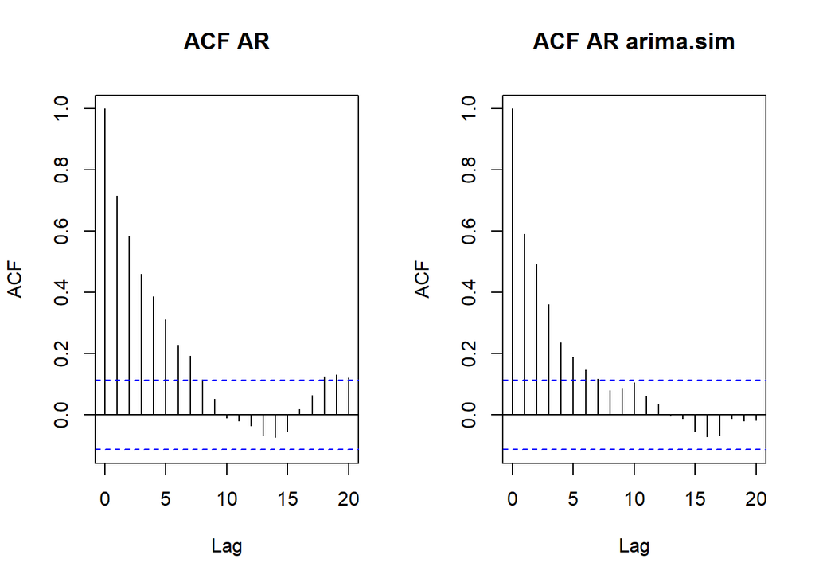

```r
par(mfrow = c(1, 2))
acf(ar, lag.max = 20, main = "ACF AR")
acf(ar2, lag.max = 20, main = "ACF AR arima.sim")
```

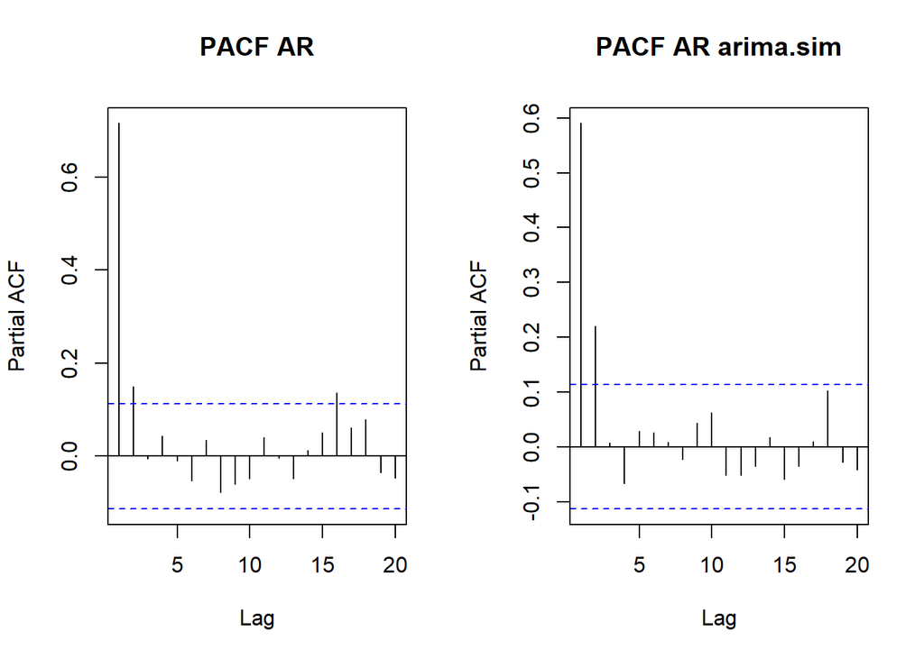

```r
par(mfrow = c(1, 2))
pacf(ar, lag.max = 20, main = "PACF AR")
pacf(ar2, lag.max = 20, main = "PACF AR arima.sim")
```

```r
TSA::eacf(ar)
```

```
## AR/MA
##   0 1 2 3 4 5 6 7 8 9 10 11 12 13
## 0 x x x x x x x o o o o  o  o  o
## 1 x o o o o o o o o o o  o  o  o
## 2 o o o o o o o o o o o  o  o  o
## 3 x x o o o o o o o o o  o  o  o
## 4 x x o o o o o o o o o  o  o  o
## 5 x x o x o o x o o o o  o  o  o
## 6 x x x x o o o o o o o  o  o  o
## 7 x x x o x x o o o o o  o  o  o
```

```r
TSA::eacf(ar2)
```

```
## AR/MA
##   0 1 2 3 4 5 6 7 8 9 10 11 12 13
## 0 x x x x x x o o o o o  o  o  o
## 1 x o o o o o o o o o o  o  o  o
## 2 o x o o o o o o o o o  o  o  o
## 3 o x o o o o o o o o o  o  o  o
## 4 x x x o o o o o o o o  o  o  o
## 5 x x x x o o o o o o o  o  o  o
## 6 x x o x o o o o o o o  o  o  o
## 7 x x x x o o o o o o o  o  o  o
```

- ACF: *Tails off* sangat jauh (di 7) sehingga tidak dapat disimpulkan
- PACF: *Cut off* pada *lag* 2
- EACF: Secara teori, segitiga nol berada pada ordo $AR(2)$ dan ordo $MA(0)$. Tetapi hal ini tidak terlalu terlihat pada arima.sim dan lebih jelas pada pembangkitan manual meskipun pada ordo 2,0 bersimbol $o$

  Kesimpulan: Model sudah sesuai dengan karakteristik $AR(2)$

## Scatterplot AntarLag

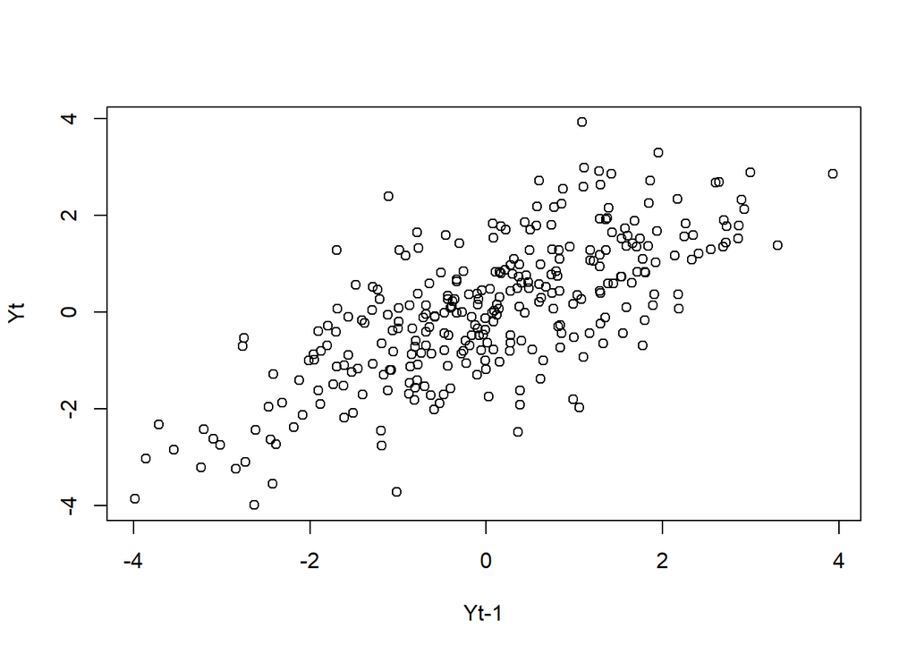

```r
#Yt
yt_ar <- ar[-1]
#Yt-1
yt_1_ar <- ar[-300]
plot(y=yt_ar,x=yt_1_ar, xlab = "Yt-1", ylab = "Yt")
```

```r
cor(yt_ar,yt_1_ar)
```

```
## [1] 0.7165728
```

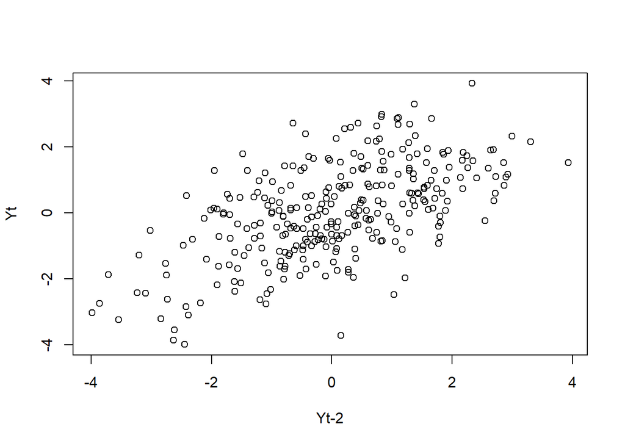

```r
#Yt
yt_ar2 <- ar[-c(1,2)]
#Yt-2
yt_2_ar <- ar[-c(299,300)]
plot(y=yt_ar2,x=yt_2_ar, xlab = "Yt-2", ylab = "Yt")
```

```r
cor(yt_ar2,yt_2_ar)
```

```
## [1] 0.5856318
```

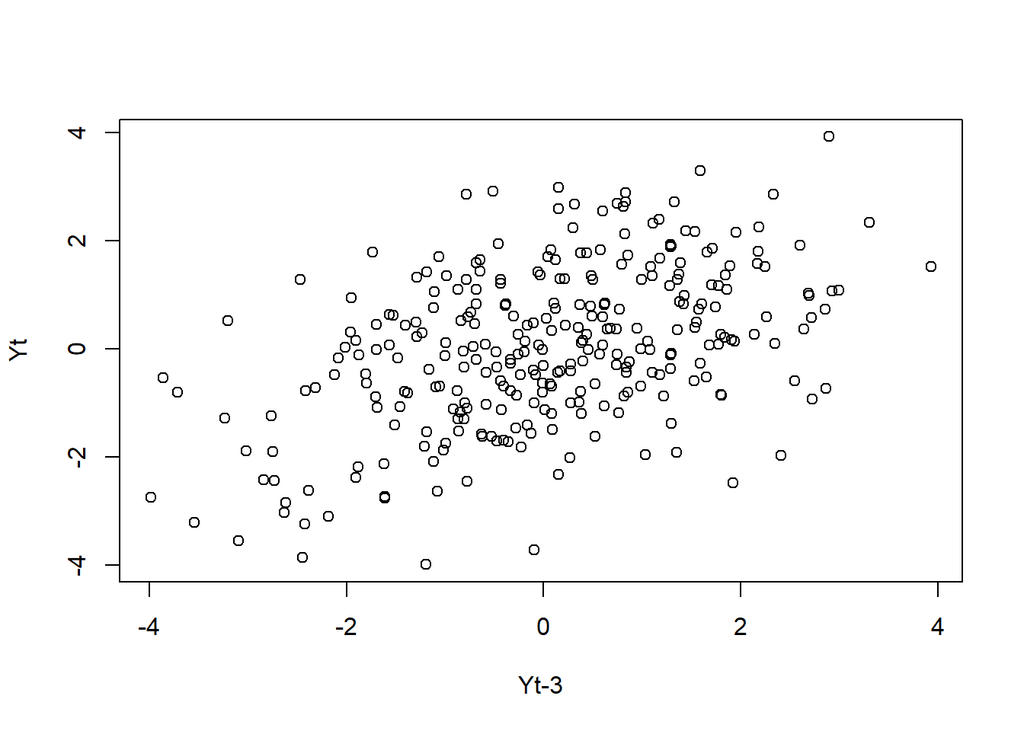

```r
#Yt
yt_ar3 <- ar[-c(1,2,3)]
#Yt-3
yt_3_ar <- ar[-c(298,299,300)]
plot(y=yt_ar3,x=yt_3_ar, xlab = "Yt-3", ylab = "Yt")
```

```r
cor(yt_ar3,yt_3_ar)
```

```
## [1] 0.4609517
```

## Autokorelasi

### ACF Bangkitan

```r
L <- 3
# banyak lag yang ingin dilihat
acf_ar  <- drop(acf(ar,  lag.max = L, plot = FALSE)$acf)
acf_ar2 <- drop(acf(ar2, lag.max = L, plot = FALSE)$acf)
```

### ACF Teoritis

```r
theo_acf <- ARMAacf(ar = c(0.5, 0.2), lag.max = 3)
```

### Perbandingan

```r
compare_ar <- data.frame(
  Lag              = 0:L,
  Empirical_manual = acf_ar,
  Empirical_sim    = acf_ar2,
  Theoretical      = theo_acf
)
print(compare_ar, row.names = FALSE)
```

```
##  Lag Empirical_manual Empirical_sim Theoretical
##    0        1.0000000     1.0000000     1.00000
##    1        0.7155777     0.5904574     0.62500
##    2        0.5847678     0.4919721     0.51250
##    3        0.4599457     0.3611993     0.38125
```

Baik model $manual$ maupun $arima.sim$ mereplikasi ACF teoretis. $arima.sim$ lebih dekat kepada teori

# Model ARMA(2,2) $𝜃_1$=0.4, $𝜃_2$=0.6, $𝜙_1$=0.5, $𝜙_2$=0.2

## Pembangkitan Model

### Manual

```r
arma <- c(1:300)
for(i in 3:300){
   arma[i] <- 0.5 * arma[i-1] + 0.2 * arma[i-2] + wn[i] + 0.4 * wn[i-1] + 0.6 * wn[i-2]
}
```

### Arima.Sim

```r
arma2 <- arima.sim(list(order=c(2,0,2), ar = c(0.5, 0.2), ma = c(0.4, 0.6)), n=300)
```

### Perbandingan

```r
compare_arma <- data.frame(
  Manual = arma,
  Sim = arma2
)
compare_arma
```

[output not shown]

[output cut: 286 more lines]

## Plot eksplorasi

### Plot Time Series

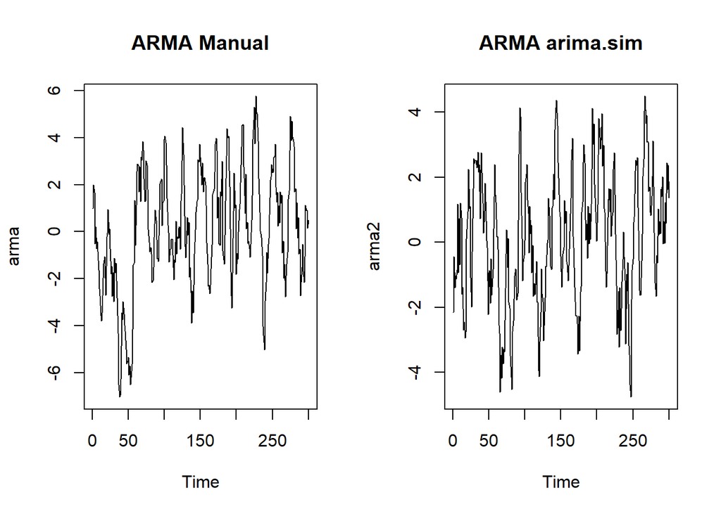

```r
par(mfrow = c(1, 2))
ts.plot(arma, main="ARMA Manual")
ts.plot(arma2, main="ARMA arima.sim")
```

### Identifikasi Stasioneritas

```r
# (a) Cek akar AR (stasioner jika semua modulus > 1)
Mod(polyroot(c(1, -phi)))   # akar polinom AR: 1 - 0.5 z - 0.2 z^2 = 0
```

```
## [1] 1.311738 3.811738
```

```r
# (b) Cek akar MA (invertibel jika semua modulus > 1)
Mod(polyroot(c(1,  theta))) # akar polinom MA: 1 + 0.4 z + 0.6 z^2 = 0
```

```
## [1] 1.290994 1.290994
```

Berdasarkan plot time series dan identifikasi stasioneritas, terlihat bahwa data ARMA(2) yang dibangkitkan stasioner dalam rataan

### Plot ACF, PACF, EACF

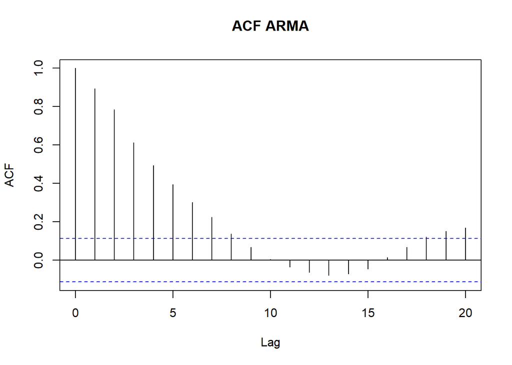

```r
acf(arma, lag.max = 20, main = "ACF ARMA")
```

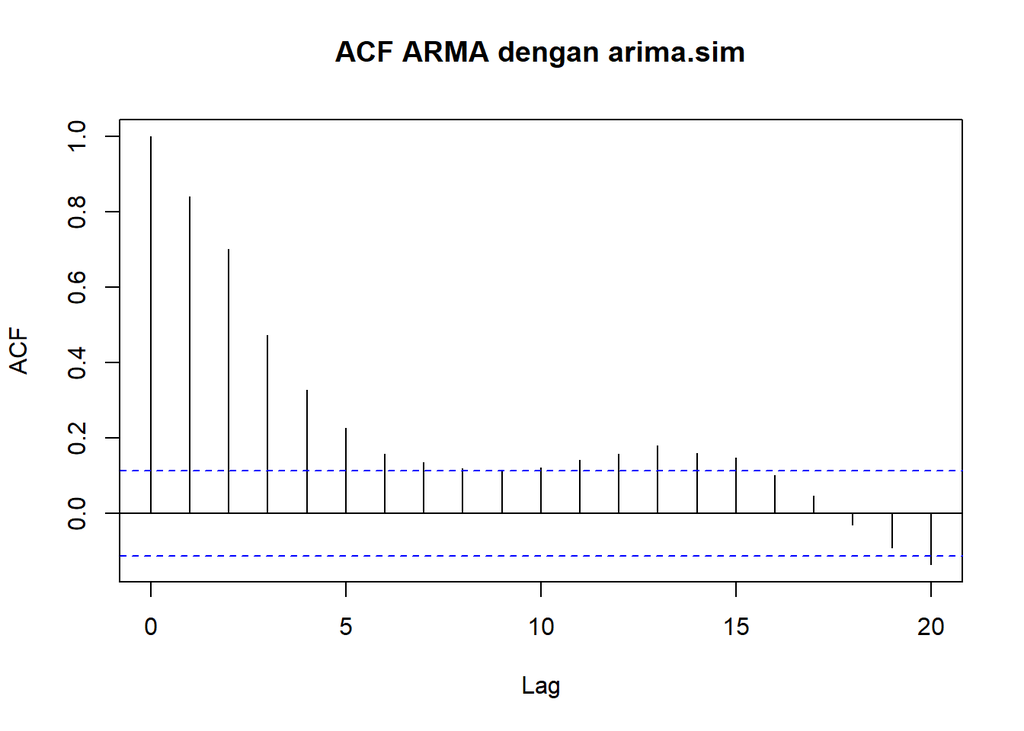

```r
acf(arma2, lag.max = 20, main = "ACF ARMA dengan arima.sim")
```

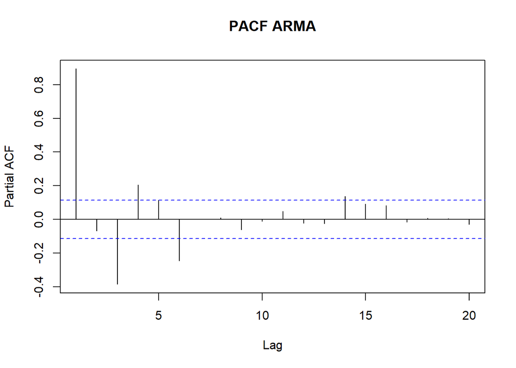

```r
pacf(arma, lag.max = 20, main = "PACF ARMA")
```

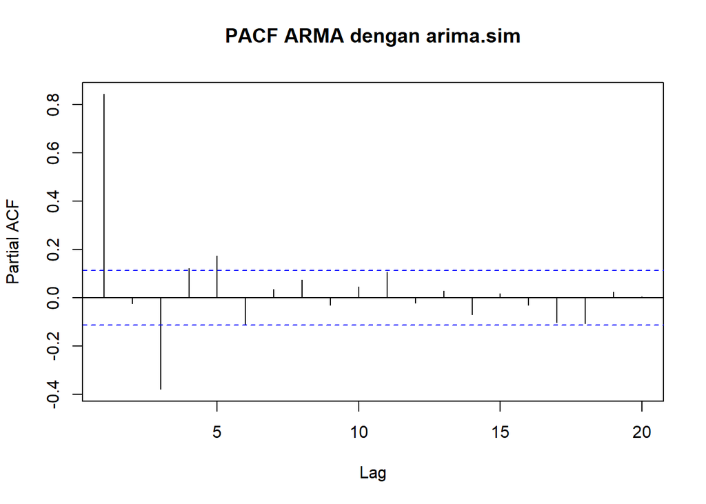

```r
pacf(arma2, lag.max = 20, main = "PACF ARMA dengan arima.sim")
```

```r
TSA::eacf(arma)
```

```
## AR/MA
##   0 1 2 3 4 5 6 7 8 9 10 11 12 13
## 0 x x x x x x x x o o o  o  o  o
## 1 o x o o o o x o o o o  o  o  o
## 2 x x o o o o x o o o o  o  o  o
## 3 x x o x o o x o o o o  o  o  o
## 4 x x x x o o x o o o o  o  o  o
## 5 x x x x x x x o o o o  o  o  o
## 6 o o x o x x o o o o o  o  o  o
## 7 x o x o x x o x o o o  o  o  o
```

```r
TSA::eacf(arma2)
```

```
## AR/MA
##   0 1 2 3 4 5 6 7 8 9 10 11 12 13
## 0 x x x x x x x x o x x  x  x  x
## 1 o x o o o o o o o o o  o  x  o
## 2 o x o o o o o o o o o  o  x  o
## 3 x x o o o o o o o o o  o  o  o
## 4 x x o o x o o o o o o  o  o  o
## 5 x x x o o o o o o o o  o  o  o
## 6 x x x o x o o o o o o  o  o  o
## 7 x x x o x o o o o o o  o  o  o
```

  Kesimpulan: Analisis plot masih belum sesuai dengan karakteristik $ARMA(2,2)$